# AS2-3: 美國的人口統計和就業資料

第 0 組

2020-03-22 21:35:32

基本的程式筆記設定，安裝、載入一些基本的套件

```r
rm(list=ls(all=T))
knitr::opts_chunk$set(comment = NA)
knitr::opts_knit$set(global.par = TRUE)
par(cex=0.8); options(scipen=20, digits=4, width=90)
if(!require(pacman)) install.packages("pacman")
pacman::p_load(dplyr)
```

以上這些程式碼請大家不要去改動

就業統計數據是政策制定者用來衡量經濟整體實力的最重要指標之一。在美國，政府使用現有人口調查（CPS）衡量失業率，該調查每月收集來自各種美國人的人口統計和就業信息。在本練習中，我們將使用講座中審查的主題以及一些使用2013年9月版的，具有全國代表性的數據集。數據集中的觀察結果代表2013年9月CPS中實際完成調查的人員，完整數據集有385個欄位，但在本練習中，我們將使用數據集CPSData.csv版本，它具有以下欄位：

- `PeopleInHousehold`: 受訪者家庭中的人數。
- `Region`: 受訪者居住的人口普查區域。
- `State`: 受訪者居住的州。
- `MetroAreaCode`: 都會區代碼，如受訪者不住都會區，則為NA；從代碼到都會區名稱的對應在`MetroAreaCodes.csv`中提供。
- `Age`: 受訪者的年齡，以年為單位。 80代表80-84歲的人，85代表85歲及以上的人。
- `Married`: 受訪者的婚姻狀況。
- `Sex`: 受訪者的性別。
- `Education`: 受訪者獲得的最高教育程度。
- `Race`: 受訪者的種族。
- `Hispanic`: 受訪者是否屬於西班牙裔。
- `CountryOfBirthcode`: 識別受訪者出生國家的代碼。從代碼到國家名稱的映射在CountryCodes.csv文件中提供。
- `Citizenship`: 受訪者的公民身份。
- `EmploymentStatus`: 受訪者的就業狀況。
- `Industry`: 受訪者的就業行業（僅在受僱的情況下可用）。

### Section-1 Loading and Summarizing the Dataset

**§ 1.1** How many interviewees are in the dataset?

```r
#把檔案讀進來
cps = read.csv("data/CPSData.csv", stringsAsFactors=F)
MetroAreaMap = read.csv("data/MetroAreaCodes.csv")
CountryMap = read.csv("data/CountryCodes.csv")
nrow(cps)
```

```
[1] 131302
```

```r
##there are 131302 interviewees are in the dataset
```

**§ 1.2** Among the interviewees with a value reported for the Industry variable, what is the most common industry of employment? Please enter the name exactly how you see it.

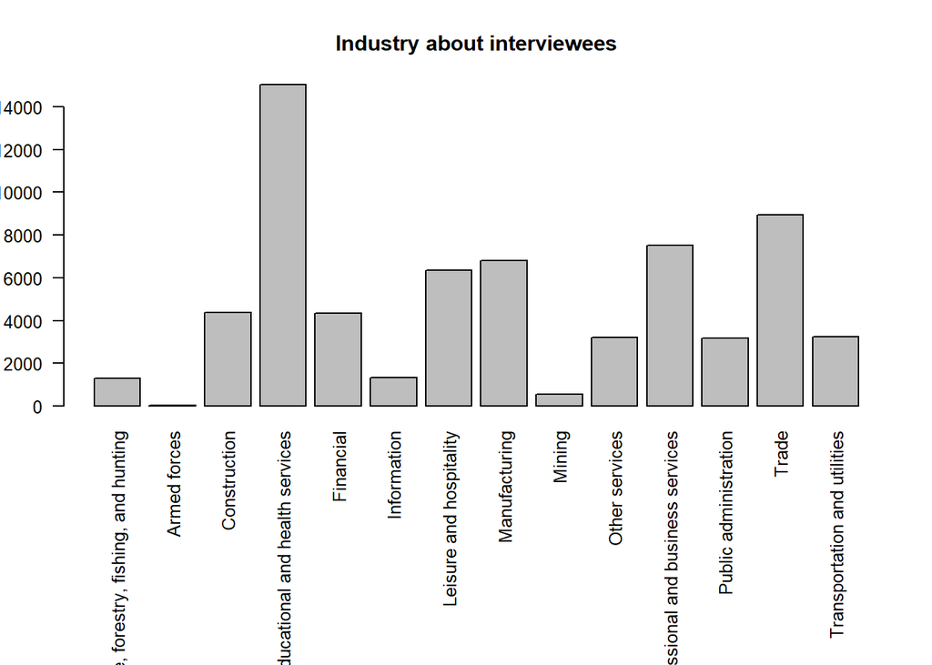

```r
#Educational and health services
#
par(mar=c(12,3,4,2),cex=0.8)
table(cps$Industry) %>% barplot(las=2, main="Industry about interviewees")
```

**§ 1.3** Which state has the fewest interviewees?

```r
#New Mexico #1102
table(cps$State) %>% sort %>% head
```

```
   New Mexico       Montana   Mississippi       Alabama West Virginia      Arkansas
         1102          1214          1230          1376          1409          1421
```

Which state has the largest number of interviewees?

```r
#California
#11570
table(cps$State) %>% sort %>% tail
```

```
    Illinois Pennsylvania      Florida     New York        Texas   California
        3912         3930         5149         5595         7077        11570
```

**§ 1.4** What proportion of interviewees are citizens of the United States?

```r
#123712
#有多少比例的人是美國公民?
#看一下Citizenship這個欄位
# unique(cps$Citizenship)

#看比例的話可以用prop.table
table(cps$Citizenship) %>% prop.table
```

```
     Citizen, Native Citizen, Naturalized          Non-Citizen
             0.88833              0.05387              0.05781
```

```r
#p.s.美國公民有幾個
sum( cps$Citizenship=='Citizen, Native' | cps$Citizenship=='Citizen, Naturalized')
```

```
[1] 123712
```

**§ 1.5** For which races are there at least 250 interviewees in the CPS dataset of Hispanic ethnicity? (Select all that apply.)

- American Indian
- Asian
- cBlack
- Multiracial
- Pacific Islander
- White

```r
#哪個種族擁有至少250個西班牙裔
#???自動篩選>250要怎麼做?
# American Indian 、Multiracial、Black、White
tapply(cps$Hispanic,cps$Race,sum) %>% sort
```

```
Pacific Islander            Asian  American Indian      Multiracial            Black
              77              113              304              448              621
           White
           16731
```